# Part II - The Effects of Borrower's Credit Profile on Loan Interest Rate

## by Dorothy Kunth

## Investigation Overview

The main goal of this investigation is to establish whether the Prosper ratings and Prosper scores have a strong effect on loan interest rate (borrower rate). Some of the characteristics of the loans that are listed are also investigated to verify which features affect the originaton of the loans. The investigation also includes whether the number of investors is driven by the borrower's income range or Prosper rating or both.

## Dataset Overview

Two dataframes will be used. One is df_prosper which has 113,937 loans and 7 variables (BorrowerRate, ProsperRating (Alpha), ProsperScore, LoanOriginalAmount, IncomeRange, EmploymentStatus and Investors). The other dataframe is df_prosper_rating which has 84853 loans and the same 7 variables.

df_prosper_rating is the dataframe created where the variables: ProsperRating (Alpha) and ProsperScore are not null. There are 29084 records with null values in ProsperRating (Alpha) and ProsperScore columns as these features are applicable only for loans originated after July 2009. Since it is a lot of records - about 25% of the total records, the df_prosper_rating will be used for analysis where the said variables are involved.

## 1. Distribution of Loan Interest Rate

Loan interest rate ranges from 0 to maximum of 49.75%. There are 2294 unique interest rates. Bins are adjusted using numpy.arange() to have an evenly spaced values within a given interval. When plotted, the distribution appears to be multimodal with peaks somewhere between 11-12%, high peak between 15-16%, another peak between 24-26% and with the highest peak between 31-32%.

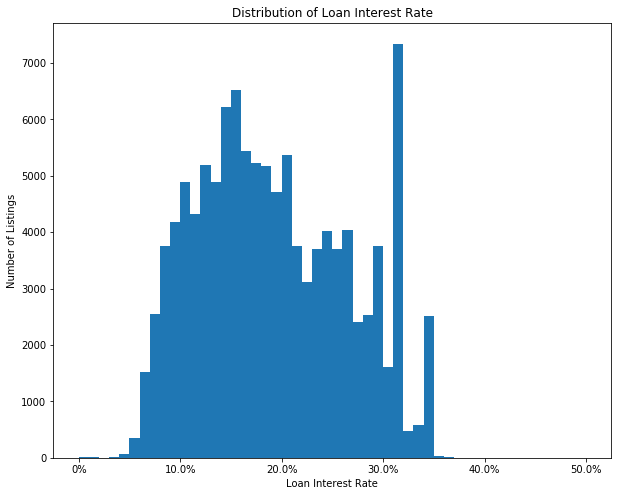

## 2. Correlation between Loan Interest Rate and Prosper Rating

The violin plot and box plot show that the borrower rate has a negative correlation with Prosper rating. The downward trend indicates that the higher the loan interest rate, the lower the rating and obviously, when the rating is high, the loan interest rate is low.

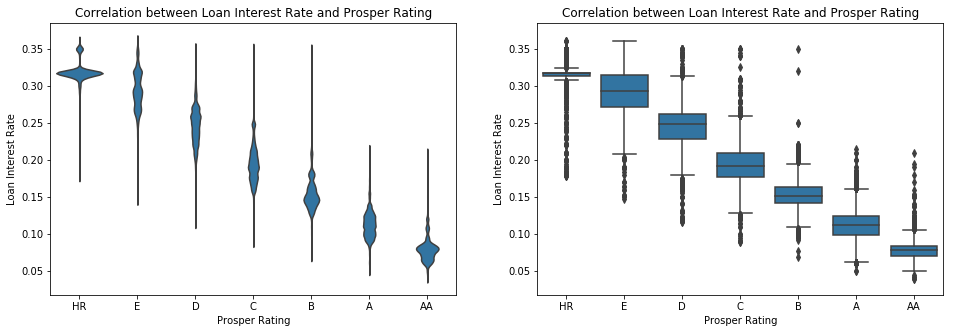

## 3. Correlation between Loan Interest Rate and Prosper Score

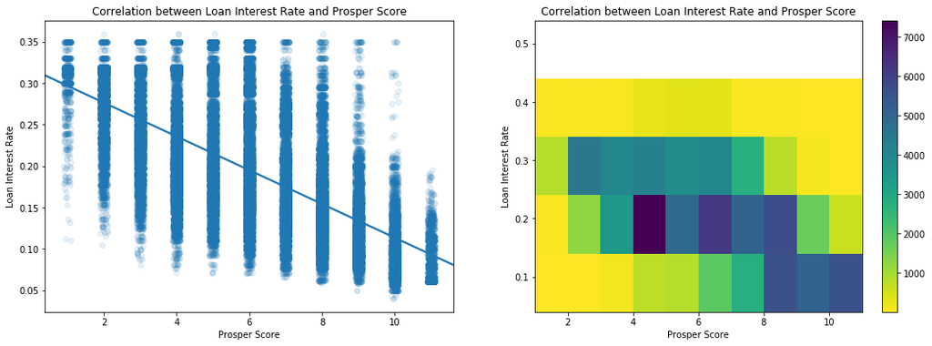

## 4. Loan Amount in USD by Loan Interest Rate and Prosper Score

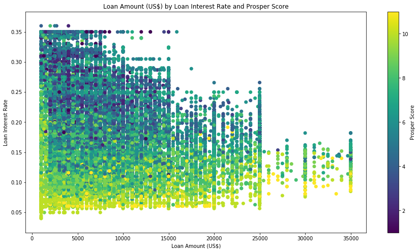

## 5. Distribution of Borrowers' Annual Income Range

The bar chart shows that the top two income ranges are USD 25,000-49,999 and USD 50,000-74,999 respectively. When combined together, it makes up the 55% of the total loan listings. Income range USD 75,000-99,000 and USD 100,000+ when combined together makes up the 30% of the total loan listings.

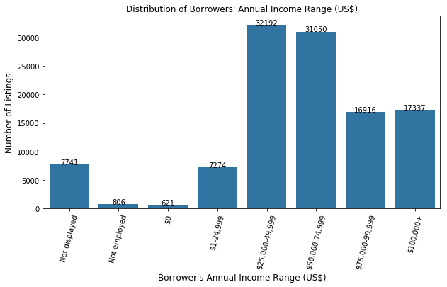

## 6. Distribution of Loan Amount

Loan amount ranges from USD 1,000 to USD 35,000. There are 2468 unique loan amounts. Bins are adjusted using numpy.arange() to have an evenly spaced values within a given interval. The distribution appears to be a bit right skewed with three very high peaks at USD 4,000, USD 10,000 and USD 15,000.

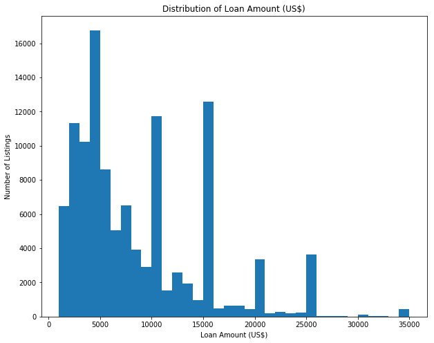

## 7. Loan Amount (USD) vs Prosper Rating, Borrower's Employment Status and Borrower's Annual Income Range

Here is a boxplot PairGrid to visualize pair-wise relationship between loan amount and the three categorical variables: Prosper rating, borrower's employment status and borrower's annual income range. For loan amount vs Prosper rating, the boxplot shows that majority of the loan amounts from USD 4,000 to USD 15,000 have the ratings of AA, A, B and C. The low ratings E and HR appear to be having a few loans in the amount below USD 5,000. Although there are a few outliers in these low ratings which shows there are a few loans in the amounts approximately between USD 4,000 to USD 18,000.

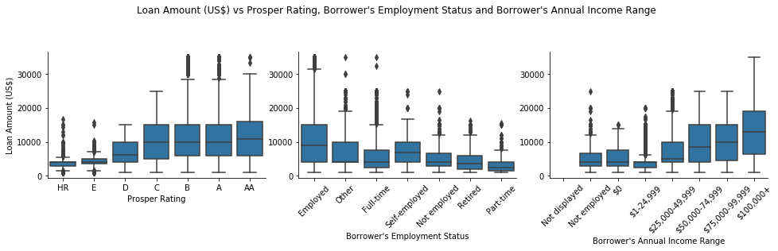

## 8. Average Number of Investors by Borrower's Annual Income Range and Prosper Rating

The bar chart shows that the number of investors has a positive relationship with Prosper rating. It indicates that the investors fund more on loans that have higher ratings. However, the number of investors does not have a direct relationship with borrower's annual income range. It shows that investors fund loans regardless of borrower's income range or whether the borrower has no income.

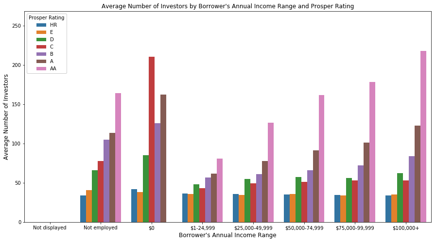